# Metagenomes analysis

Set up

```r
rm(list=ls()) #clear workspace

library(labdsv)
library(tidyverse)
library(reshape2)
library(ggplot2)
library(vegan)
library(gplots)
```

Load metadata for all analyses

```r
metadata <- read.csv("data/sample-summary-timecourse-RG.csv", row.names = 1)

##Two samples (B9 and C8) failed in the PhyloFlash pipeline repeatedly and were dropped from the analysis
metadata <- subset(metadata, well_MiGS !=c("B9","C8"))
```

##Phyloflash - import

Parsing the PhyloFlash output. The filename was added to each line.

```r
file_list <- list.files(path = "data/mgs_phyloflash_data/abund",     # Identify all csv files in folder
                       pattern = "*.csv", full.names = TRUE)

dataset = data.frame()
for (file in file_list){
    print(file)
    temp = read.csv(file, header = F)
    dataset = rbind(dataset,temp)
}
rm(temp)

dataset <- dataset %>%
  separate(V2, c("counts","sample"), sep=" ")%>%
  separate("sample", c(NA,"well",NA), sep="[_-]")

dim(dataset)

length(unique(dataset$V1))

length(unique(dataset$well))

##reshape data with dcast
counts.m <- dcast(dataset, V1~well, value.var= "counts")
rm(dataset)

#convert NA to 0
counts.m[is.na(counts.m)] = 0

##assign rownames
rownames(counts.m) <- counts.m$V1
counts.m <- counts.m %>% select(-V1)

##make dataframe numeric
counts.m[] <- lapply(counts.m, as.numeric)

##save output before normalization
saveRDS(counts.m, "data_deriv/mgs_phyloflash-counts-absolute.RDS")
```

normalization of PhyloFlash output

```r
counts_absolute.m <- readRDS("data_deriv/mgs_phyloflash-counts-absolute.RDS")

##sum of reads per sample
totalreads <- colSums(counts_absolute.m)

range(counts_absolute.m)
```

```
[1]    0 2060
```

```r
#normalize
counts.m <- sweep(counts_absolute.m,MARGIN=2,FUN="/",STATS=totalreads)

range(counts.m)
```

```
[1] 0.0000000 0.1618606
```

```r
##convert to percentages
counts.m <- counts.m*100

counts.m <- t(counts.m)

range(counts.m)
```

```
[1]  0.00000 16.18606
```

```r
rowSums(counts.m) ##should be 100 if it's correctly normalized
```

```
 A1 A10 A11 A12  A2  A3  A4  A5  A6  A7  A8  A9  B1 B10 B11 B12  B2  B3  B4  B5  B6  B7  B8
100 100 100 100 100 100 100 100 100 100 100 100 100 100 100 100 100 100 100 100 100 100 100
 C1 C10 C11 C12  C2  C3  C4  C5  C6  C7  C9
100 100 100 100 100 100 100 100 100 100 100
```

```r
#Clean up the data and add taxonomy
##Create new column names

taxonomy <- as.data.frame(colnames(counts.m))
taxonomy <- taxonomy %>% separate("colnames(counts.m)", c("Kingdom","Phylum","Class","Order","Family","Genus","Species"), sep =";", remove=F)

taxonomy$names <- paste0(taxonomy$Order, "_", taxonomy$Family, "_", taxonomy$Genus, "_", taxonomy$Species)

colnames(counts.m) <- taxonomy$names

##Remove any hits to Eukaryotes
taxonomy <- subset(taxonomy, Kingdom=="Bacteria")
taxonomy <- subset(taxonomy, !Order=="Chloroplast")
taxonomy <- subset(taxonomy, !Family=="Mitochondria")

counts.m <-counts.m[,colnames(counts.m) %in% taxonomy$names]

saveRDS(counts.m, "data_deriv/mgs_phyloflash-counts-bacterial.RDS")
saveRDS(taxonomy, "data_deriv/mgs_phyloflash-counts-bacterial-taxonomy.RDS")
```

Subset for most abundant taxa: we focused only on the most abundant taxa (that reached at least 1% relative abundance in one timepoint), based on previous work: Datta, M., Sliwerska, E., Gore, J. et al. Microbial interactions lead to rapid micro-scale successions on model marine particles. Nat Commun 7, 11965 (2016). https://doi.org/10.1038/ncomms11965

```r
counts.m <- readRDS("data_deriv/mgs_phyloflash-counts-bacterial.RDS")
taxonomy <- readRDS("data_deriv/mgs_phyloflash-counts-bacterial-taxonomy.RDS")

#Use binary index to identify abundant taxa
counts.binary <- counts.m

counts.binary[counts.binary < 1] <- 0
counts.binary[counts.binary > 1] <- 1

range(counts.binary)
```

```
[1] 0 1
```

```r
##Subset counts.m by the binary index.
##if the sum of any column (ie taxa) in counts.binary is greater than 0, it is more than 1% in at least one sample
counts.m <-counts.m[,colSums(counts.binary[])>0]

rm(counts.binary)

#Sort data by the two treatment conditions based on the metadata.
counts.m <- counts.m[match(metadata$well_MiGS,rownames(counts.m)),]


#Subset taxonomy to match most abundant taxa list

taxonomy <- taxonomy[match(colnames(counts.m), taxonomy$names),]

##replace "Oceanospirillales" and "Cellvibrionales" with Pseudomonadales based on updated nomenclature
taxonomy$Order_updated <- taxonomy$Order
taxonomy$Order_updated <- taxonomy$Order_updated %>% str_replace_all("Oceanospirillales", "Pseudomonadales")

taxonomy$Order_updated <- taxonomy$Order_updated %>% str_replace_all("Cellvibrionales", "Pseudomonadales")

saveRDS(counts.m, "data_deriv/mgs_phyloflash-counts-top1perc.RDS")
saveRDS(taxonomy, "data_deriv/mgs_phyloflash-taxonomy-top1perc.RDS")
```

##Fig. 1a- Bar plot of enriched taxa per order

```r
#import data
counts.m <- readRDS("data_deriv/mgs_phyloflash-counts-top1perc.RDS")
taxonomy <- readRDS("data_deriv/mgs_phyloflash-taxonomy-top1perc.RDS")

counts.ctrl <- counts.m[1:17,]
counts.vit <- counts.m[18:34,]

##sum across each condition to make a combined sample

##check that the order matches
match(colnames(counts.ctrl), taxonomy$names)
```

```
 [1]  1  2  3  4  5  6  7  8  9 10 11 12 13 14 15 16 17 18 19 20 21 22 23 24 25 26 27 28 29
[30] 30 31 32 33 34 35 36 37 38 39 40 41 42 43 44 45 46 47 48 49 50 51 52 53 54 55 56 57 58
[59] 59 60
```

```r
unique(taxonomy$Order_updated)
```

```
 [1] "(Bacteria)"            "(Bacteroidia)"         "Cytophagales"
 [4] "Flavobacteriales"      "Campylobacterales"     "Fibrobacterales"
 [7] "(Proteobacteria)"      "Rhodobacterales"       "SAR11 clade"
[10] "(Gammaproteobacteria)" "Alteromonadales"       "Burkholderiales"
[13] "Pseudomonadales"       "Legionellales"         "SAR86 clade"
[16] "Thiomicrospirales"     "Vibrionales"
```

```r
taxonomy %>% count(Order_updated, sort=T)
```

| Order_updated | n |
| --- | --- |
| Pseudomonadales | 16 |
| Vibrionales | 8 |
| Flavobacteriales | 7 |
| Alteromonadales | 6 |
| Campylobacterales | 4 |
| SAR11 clade | 4 |
| Fibrobacterales | 3 |
| Rhodobacterales | 2 |
| SAR86 clade | 2 |
| (Bacteria) | 1 |

[output cut: 7 more lines]

```r
##Label some taxa as "Other" based on Datta 2016

other <- c("SAR86 clade","SAR11 clade","(Bacteria)", "(Bacteroidia)", "(Gammaproteobacteria)", "(Proteobacteria)","Burkholderiales","Cytophagales","Legionellales","Thiomicrospirales")

taxonomy$Order_simple <- taxonomy$Order_updated

##Add the col index in the y position to put "Other" only in the simple column.
taxonomy[taxonomy$Order_simple %in% other,"Order_simple"] <- "Other"

taxonomy$Order_simple <- factor(taxonomy$Order_simple)

taxonomy$Order_simple
```

```
 [1] Other             Other             Other             Flavobacteriales
 [5] Flavobacteriales  Flavobacteriales  Flavobacteriales  Flavobacteriales
 [9] Flavobacteriales  Flavobacteriales  Campylobacterales Campylobacterales
[13] Campylobacterales Campylobacterales Fibrobacterales   Fibrobacterales
[17] Fibrobacterales   Other             Rhodobacterales   Rhodobacterales
[21] Other             Other             Other             Other
[25] Other             Alteromonadales   Alteromonadales   Alteromonadales
[29] Alteromonadales   Alteromonadales   Alteromonadales   Other
[33] Pseudomonadales   Pseudomonadales   Pseudomonadales   Pseudomonadales
[37] Other             Pseudomonadales   Pseudomonadales   Pseudomonadales
[41] Pseudomonadales   Pseudomonadales   Pseudomonadales   Pseudomonadales
[45] Pseudomonadales   Pseudomonadales   Pseudomonadales   Pseudomonadales
[49] Pseudomonadales   Other             Other             Other
[53] Vibrionales       Vibrionales       Vibrionales       Vibrionales
[57] Vibrionales       Vibrionales       Vibrionales       Vibrionales
8 Levels: Alteromonadales Campylobacterales Fibrobacterales Flavobacteriales ... Vibrionales
```

```r
##Calculate the average relative abundance per conditon
taxonomy$Control <- colSums(counts.ctrl)/nrow(counts.ctrl)
taxonomy$Vitamins <- colSums(counts.vit)/nrow(counts.vit)
```

Plot as log ratio

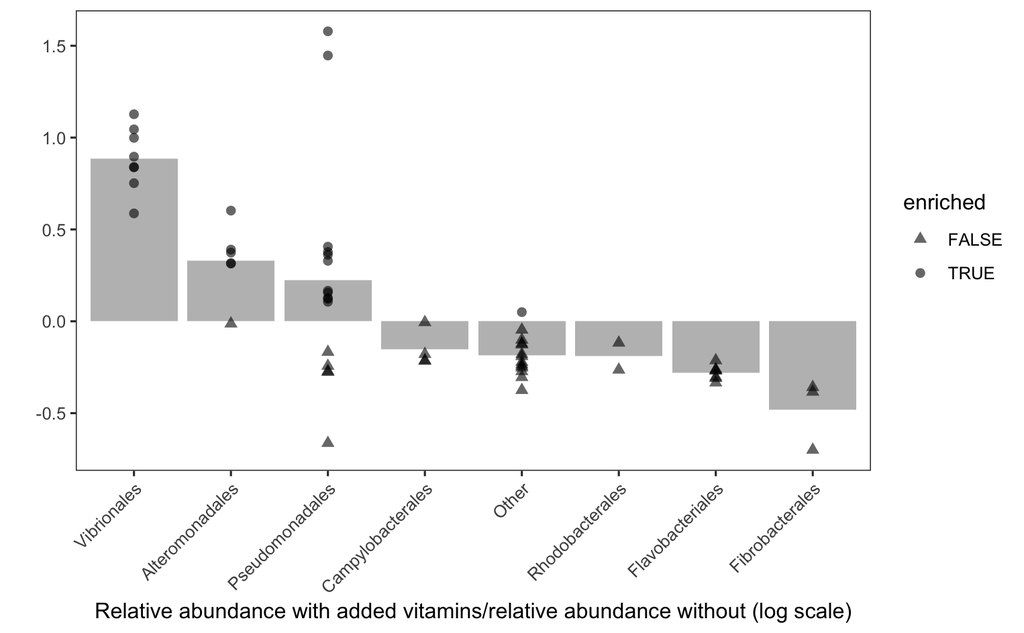

```r
taxonomy$log_ratio <- log10(taxonomy$Control/taxonomy$Vitamin)

summary_sums <- taxonomy %>%
  group_by(Order_simple) %>%
  summarise(across(c("log_ratio"), mean))

summary_sums <-summary_sums[order(summary_sums$log_ratio,decreasing=T),]

summary_sums$Order_simple <- factor(summary_sums$Order_simple,levels=summary_sums$Order_simple)

summary_sums <-na.omit(summary_sums)

##Overlay with all datapoints. Order it in the same order as the summary sums dataframe
taxonomy$Order_simple <- factor(taxonomy$Order_simple,levels=summary_sums$Order_simple)

##add shapes based on taxa enriched in each condition

taxonomy$enriched <- taxonomy$log_ratio >0

ggplot()+
  geom_bar(data=summary_sums, aes(x=Order_simple,y=log_ratio),stat="identity",fill="grey",position=position_dodge())+
  geom_point(data=taxonomy, aes(x = Order_simple, y=log_ratio, shape=enriched), alpha=0.6,size=2)+
  scale_shape_manual(values=c(17,16))+
  theme_bw()+
  theme(panel.grid.major = element_blank(), panel.grid.minor = element_blank(),
        axis.text.x = element_text(angle = 45, vjust = 1, hjust=1)) +
  ylab("") + xlab("Relative abundance with added vitamins/relative abundance without (log scale)")

ggsave("figures/rel-abund-bar-plot-1A.svg",device="svg", height=4, width=4)
```

```r
NA
```

##Fig. S1- Heatmap Visualize data as heatmap over time (Fig. S1)

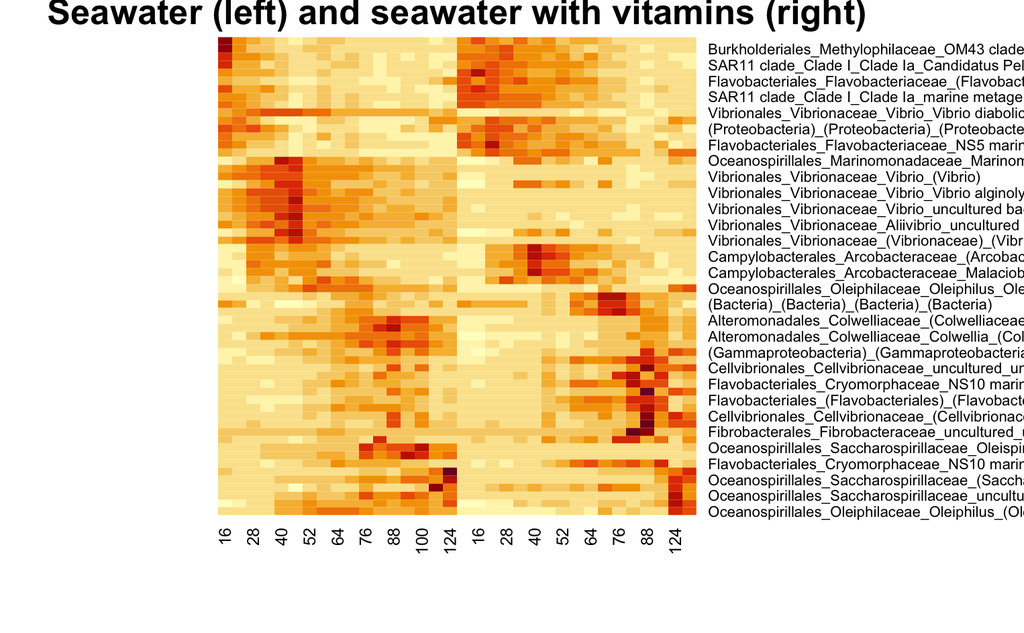

```r
#load data
counts.m <- readRDS("data_deriv/mgs_phyloflash-counts-top1perc.RDS")
taxonomy <- readRDS("data_deriv/mgs_phyloflash-taxonomy-top1perc.RDS")

#For visualization, sort the taxa so that the maximum abundance matches the order of the timepoints

order.taxa <- as.data.frame(colnames(counts.m))

##Print the well in which the abundance of each taxon peaks
order.taxa$max <- colnames(t(counts.m))[max.col(t(counts.m), ties.method = "first")]

#Also print the maximal value to help sort within samples
order.taxa$max_val <-apply(counts.m[, 1:ncol(counts.m)], 2, max)

order.taxa <- cbind(order.taxa,metadata[match(order.taxa$max,metadata$well_MiGS),])

#arrange by desc(max_val) to organize the numeric values in descending order
order.taxa <- order.taxa %>% arrange(timepoint, type,desc(max_val))

counts.m <- counts.m[,match(rev(order.taxa$`colnames(counts.m)`),colnames(counts.m))]

#Visualize heatmap
heatmap(t(counts.m), Colv=NA, Rowv=NA, main="Seawater (left) and seawater with vitamins (right)", labCol=metadata$time_hrs)
```

Show mean value for duplicates at each timepoint

```r
##calculate the mean for each two timepoints

##first add in metadata
merged <- cbind(metadata,counts.m)

range(counts.m)
```

```
[1]  0.00000 16.18606
```

```r
merged <- melt(merged, id.vars = colnames(metadata))

##calculate mean
merged <- merged %>% group_by(type, time_hrs, variable) %>%
  summarize_at(vars(value), list(name = mean))

merged$ave_sample <- paste0(merged$time_hrs,"_",merged$type)

counts.average <- dcast(merged, variable~ave_sample, value.var = "name")

#clean up rownames
rownames(counts.average) <- counts.average[,1]
counts.average <- counts.average[,-1]

#make numeric and matrix
counts.average[] <- lapply(counts.average, as.numeric)

counts.average <- as.matrix(counts.average)

class(counts.average)
```

```
[1] "matrix" "array"
```

```r
#manually set sample order based on time and group
sample_order <- c("16_ctrl", "28_ctrl", "40_ctrl", "52_ctrl", "64_ctrl", "76_ctrl", "88_ctrl","100_ctrl","124_ctrl","16_vit", "28_vit", "40_vit", "52_vit", "64_vit", "76_vit", "88_vit","100_vit","124_vit")

##ensure that the two lists have no differences before matching
setdiff(sample_order, colnames(counts.average))
```

```
character(0)
```

```r
setdiff(colnames(counts.average), sample_order)
```

```
character(0)
```

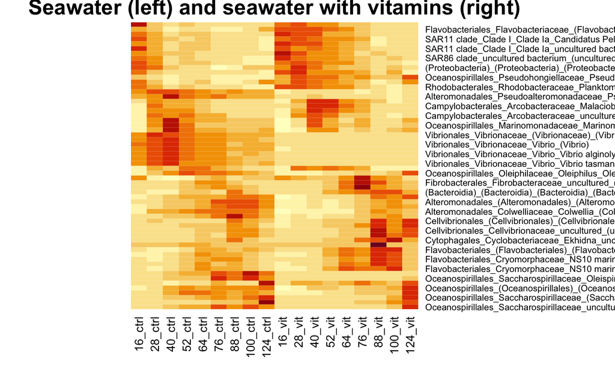

```r
counts.average <- counts.average[,match(sample_order, colnames(counts.average))]

##since data will be normalized per taxon below, we will sort by timepoint and order this time
order.taxa <- merge(order.taxa, taxonomy, by.x="colnames(counts.m)", by.y="names")
order.taxa <- order.taxa %>% arrange(timepoint,Order)

counts.average <- counts.average[match(rev(order.taxa$`colnames(counts.m)`),rownames(counts.average)),]


#Visualize heatmap
heatmap(counts.average, Colv=NA, Rowv=NA, main="Seawater (left) and seawater with vitamins (right)")
```

Normalize each individual trajectory to its maximum value (as in Datta 2016).

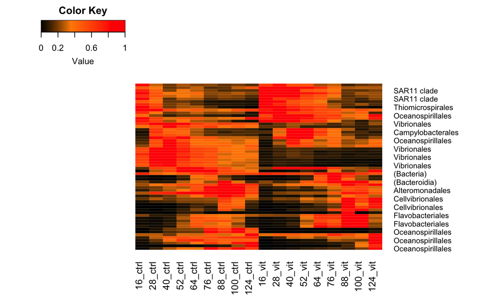

```r
#normalize by max value in each column (check orientation of your table)
counts.average <- t(counts.average)
counts.average.norm <- sweep(counts.average,MARGIN=2,STATS=apply(counts.average, 2, max),FUN="/")
counts.average.norm <- t(counts.average.norm)

#reverse order for correct visualization using heatmap.2
counts.average.norm <- counts.average.norm[nrow(counts.average.norm):1, ]

heatMapCols <- colorRampPalette(c("black", "darkorange", "red"),bias=1.5)(599)

heatmap.2(counts.average.norm, Colv=NA, Rowv=NA, dendrogram = "none", col=heatMapCols, trace="none", cexRow = 0.8,
          density.info = "none",
          margins=c(5,10),
          scale="none",
          colsep=NULL,rowsep=NULL,
          labRow = order.taxa$Order
          #labCol = c("16","28","40","52","64","76","88","100","124","16","28","40","52","64","76","88","100","124")
          )
```

##Fig S1- beta diversity

Beta diversity as PCoA plot

```r
#load full dataframe
counts.m <- readRDS("data_deriv/mgs_phyloflash-counts-bacterial.RDS") ##full dataframe

##remove first column which is just "bacteria"
counts.m <- counts.m[,-1]

##match the order of the metadata to the data
metadata <- metadata[match(rownames(counts.m),metadata$well_MiGS),]

dim(counts.m)
```

```
[1]   34 4657
```

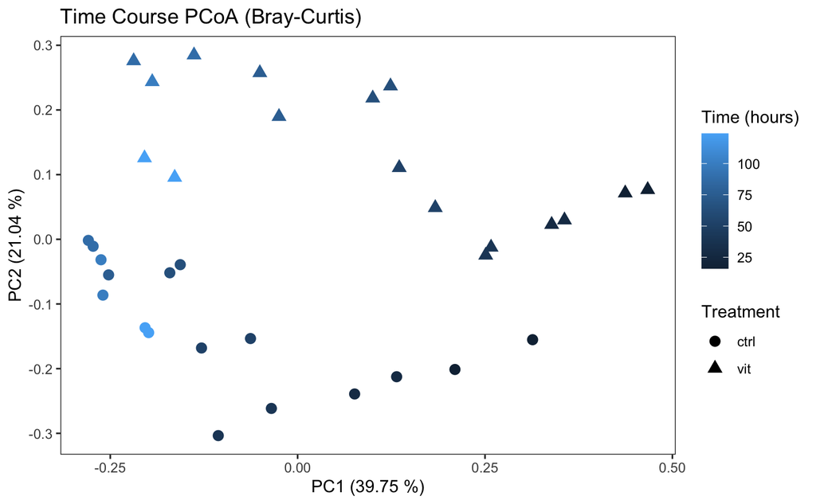

```r
#Calculate Bray Curtis distances
counts_dist <- vegdist(counts.m)
counts_pcoa <- pco(counts_dist, k = 2)

#Normalize axis by eigenvalues

eig_bray <- eigenvals(counts_pcoa)
exp_var_bray <- eig_bray / sum(eig_bray)
exp_var_bray_2 <- round(((exp_var_bray[1:2])*100),2)

metadata$dim1.pcoa.bray <- counts_pcoa$points[, 1]
metadata$dim2.pcoa.bray <- counts_pcoa$points[, 2]


#Plot PCoA

ggplot(metadata, aes(x=dim1.pcoa.bray, y=dim2.pcoa.bray, shape = type, color = time_hrs)) + geom_point(size=3) +
labs(shape= "Treatment", color = "Time (hours)", y=paste("PC2 (",exp_var_bray_2[2], " %)", sep = ""), x= paste("PC1 (",exp_var_bray_2[1], " %)", sep = ""), title="Time Course PCoA (Bray-Curtis)") +
    theme_bw()+
  theme(panel.grid.major = element_blank(), panel.grid.minor = element_blank())
```

```r
NA
NA
```

##Fig 1b- Chitinase abundance over time Reads were mapped to chitinase genes using hmmer and a custom database of profile hidden Markov models of proteins involved in growth on chitin. The output was filtered for iEval < 1e-9, score > 30.

Based on: Szabo, R. E. et al. Historical contingencies and phage induction diversify bacterioplankton communities at the microscale. Proc. Natl. Acad. Sci. U. S. A. 119, e2117748119 (2022).

```r
##Import filtered output of hmmer
hmm <- read.table("data/mgs_hmm_filteredChitinases.txt")

##cast it and order to match metadata
hmm.m <- dcast(hmm, query_name ~ sample, fun.aggregate = length)
rownames(hmm.m) <- hmm.m[,1]

hmm.m <- hmm.m[,-1]

hmm.m <- hmm.m[,match(metadata$well_MiGS, colnames(hmm.m))]

hmm_metadata <- hmm_metadata[match(rownames(hmm.m),hmm_metadata$query_name),]

rownames(hmm.m) <- hmm_metadata$name

##normalize based on the reads per sample
hmm.m <- sweep(hmm.m, 2, as.numeric(metadata$trimmed_reads), "/")

hmm.m <- hmm.m*100
```

Generate line graph

```r
meta_hmm <- cbind(metadata, t(hmm.m))

meta_hmm <- melt(meta_hmm, measure.vars = rownames(hmm.m))

meta_hmm<- cbind(meta_hmm, "PFAM_class" = hmm_metadata[match(meta_hmm$variable,hmm_metadata$name),]$type)

colnames(meta_hmm)
```

```
 [1] "number"         "timepoint"      "type"           "sample.name"    "time_hrs"
 [6] "day"            "sequencing"     "well_MiGS"      "migs_name"      "notes"
[11] "raw_reads"      "trimmed_reads"  "dim1.pcoa.bray" "dim2.pcoa.bray" "variable"
[16] "value"          "PFAM_class"
```

```r
meta_hmm <- subset(meta_hmm, variable!="nagE")

meta_hmm <- subset(meta_hmm, variable!="nagA")

meta_hmm <- subset(meta_hmm, variable!="nagK")


##going to aggregate again, but this time collapse all together
hmm_agg <-meta_hmm %>%
 group_by(type,migs_name, time_hrs)%>%
  summarise(reads_norm=sum(value))
colnames(hmm_agg)
```

```
[1] "type"       "migs_name"  "time_hrs"   "reads_norm"
```

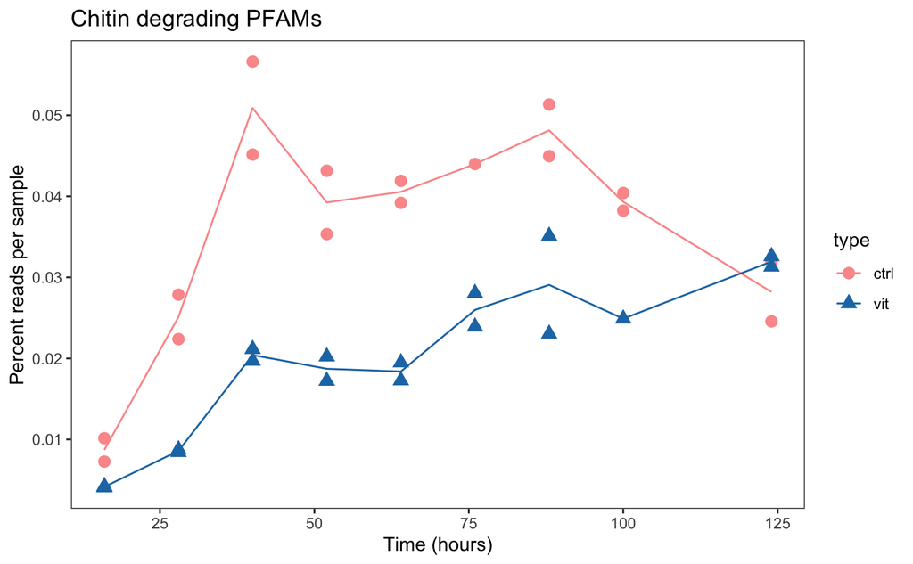

```r
colnames(hmm_agg) <- c("type","migs_name","hours","reads_norm")

ggplot(hmm_agg, aes(x=hours, y=reads_norm, color=type, shape=type, group=type)) +
  scale_color_manual(values=c("#fb9a99", "#1f78b4"))+
  geom_point(size=3)+
  stat_summary(geom = "line", fun = mean)+
  labs(y="Percent reads per sample", x= "Time (hours)", title=paste0("Chitin degrading PFAMs")) +
  theme_bw()+
  theme(panel.grid.major = element_blank(), panel.grid.minor = element_blank())
```